# *Feasibility*

Philosophy 101 - Class 21

Brian Weatherson

weath@umich.edu

University of Michigan

November 8, 2023

# A Game

## A Game

We’ll start with something that might feel very different from climate change. But hopefully the relevance will become clear in a second.

This is a version of what’s sometimes called an investment game in economics.

## A Game

Pretend that we’re playing the following two stage game.

1. First, each of you will choose to ‘invest’ 0, 1, 2, 3, or 4 dollars.
2. Then, I’ll add up how much everyone invested, multiply the amount by 5, and distribute that equally among everyone, whether you invested or not.

On the next slide I’ll do an iClicker poll about this game, and it’s important that people answer quickly, so load up iClicker now.

## Question

In the pretense, how much do you ‘invest’?

1. $0
2. $1
3. $2
4. $3
5. $4

## Analogy

- Each person in the room is like a country.
- The ‘investment’ levels are like how much we spend on climate abatement.
- The gains in step 2 are how much we each benefit from having a cleaner planet.

## Three Characteristics of the Game

1. Everyone is better off if everyone puts in $4 rather than everyone putting in $0.
2. Whatever everyone else does, the world as a whole (all the students, or all the countries) are better off if you put in $4 rather than $0.
3. Whatever everyone else does, you are better off putting in $0 rather than $4.

## Three Characteristics of the Analogy

1. Everyone is better off if everyone spends a lot on climate abatement rather than nothing.
2. Whatever everyone else does, the world as a whole (all the students, or all the countries) are better off if your country spends a lot rather than nothing.
3. Whatever everyone else does, you are better off spending nothing rather than a lot.

## More Realistic Analogy

- Point 3 might seem too strong.
  - Remember all that stuff about pollution in India from last time.
- More realistic games might make it so that if no one is doing anything, so there is some really low-hanging fruit, you’re better off doing it.
  - In the game this might be like investing $1.
  - In the real world, it might be getting people away from using wood stoves in cities.

## How Would You Solve This?

Earlier I told you to act quickly in the game. What might you have done differently if you had more time?

## Possible Moves

1. Talk
2. Informal agreements
3. Binding agreements
4. Informal agreements with informal sanctions

# Feasibility

## Pareto Optimal

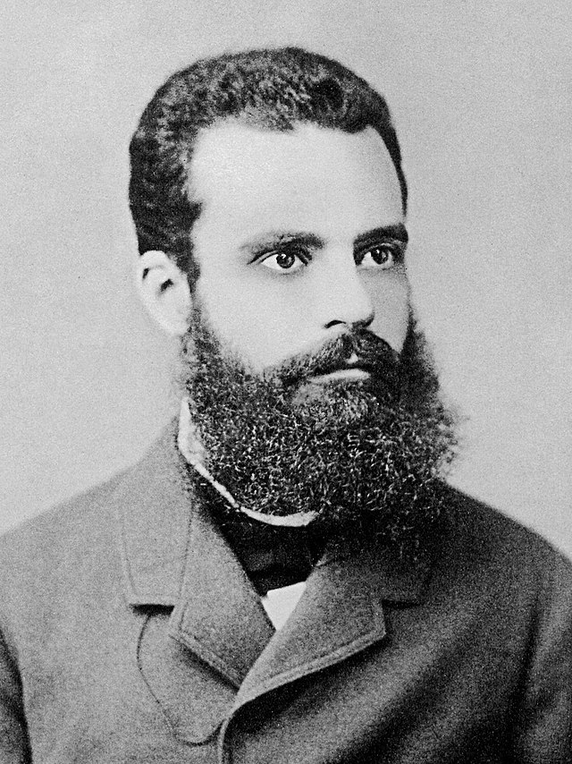

Vilfredo Pareto (1848-1923)

One situation is a **Pareto improvement** on another if someone is better off, and no one is worse off.

A situation is **Pareto optimal** if there are no possible improvements on it.

## International Paretianism

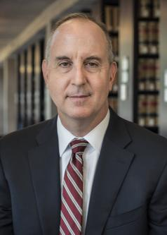

Eric Posner

Eric Posner and David Weisbach argue that we should focus our climate actions on international agreements that are Pareto improvements on the present situation.

## Why International Paretianism?

- They don’t think we should make every **person** better off.
- Rather, they think we should make every **country** better off.
- By this, they mean that we should increase the sum of the well-being of the people in each country.
- The alternatives, they argue, are not **feasible**.

## Back to the Game

In the game we started with, this would give the intuitively right solution.

- An agreement to all invest $4 would leave everyone much better off (in fact $16 better off) than doing nothing.
- So they recommend that we work towards that kind of agreement.
- And that sounds like pretty good advice I guess.

## International Paretianism

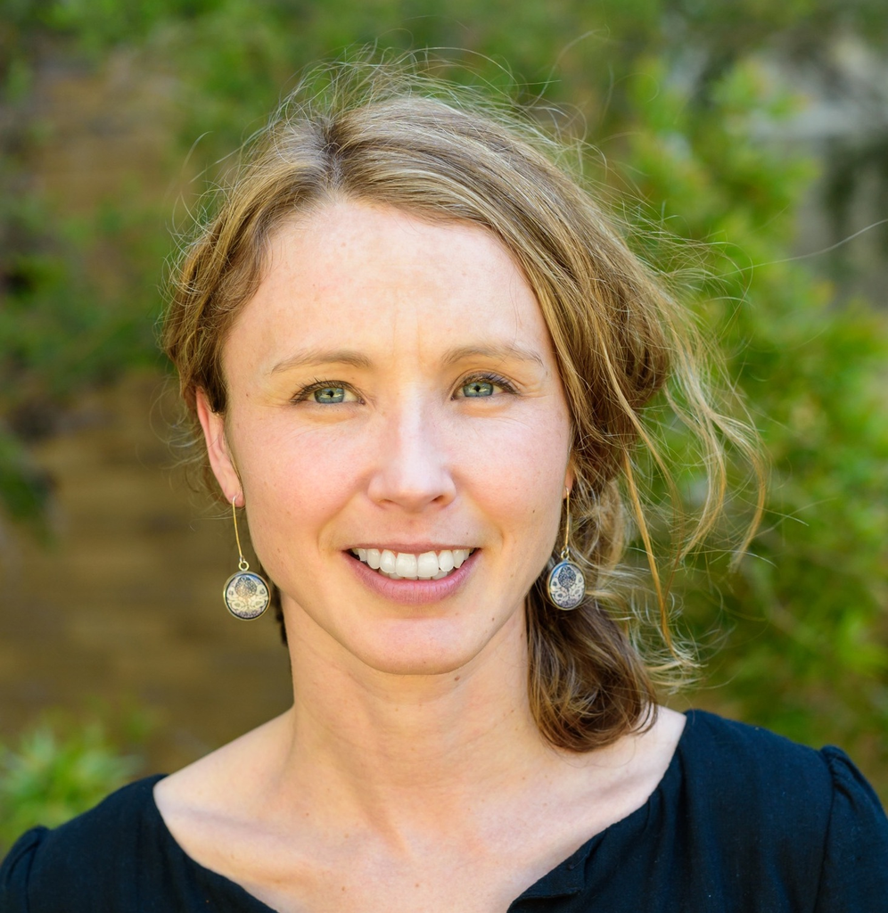

Katie Steele

Katie Steele offers a bunch of criticisms of this, and I want to focus on two of them.

The objections are going to be from opposite directions, and between them they suggest that there is something rather unstable about this position.

# Objection From Morality

## Drowning Child

Here’s a variant of a famous thought experiment by another Australian philosopher, Peter Singer.

- There is a child drowning in a shallow pond.
- Lots of us are standing nearby.
- Any one of us could walk in and rescue the child.
- But doing so would damage our shoes, and besides the water is rather cold.

## Feasibility

- It would be very bad if none of us rescued the child.
- It would also be bad if we all said it wasn’t feasible for us to rescue the child because well what was in it for us?
- Exactly what feasibility comes to is very hard, but surely it doesn’t rule out that kind of rescue.

## Drownings

One of the things that might happen if we don’t do anything about climate change is that Tuvalu might literally go under water.

And it’s not just that Tuvalu might go under water, it might do so because of our actions.

We aren’t just bystanders in this case; we (collectively) are responsible for the problem.

## Cross Time

But Posner and Weisbach can say something important here.

- There is a big difference between the drowning child case and action on climate.
- Anything worth doing on climate will have to be maintained over time.
- It doesn’t help much to turn off coal power plants if the next government can simply turn them back on.

## Two Kinds of Cooperation

Two kinds of cooperation seem central to action on climate change.

1. Cooperation across countries.
2. Cooperation within countries across time, e.g., between successive governments.

Maybe you can convince yourself the first is not essential; e.g., America can and should simply do better.

But the second is essential, and maybe Posner and Weisbach can argue that asking countries to act against their self-interest is incompatible with it.

# Objection from Cynicism

## Two Comparisons

1. Everyone following the agreement is better than no one following the agreement.
2. Your following the agreement is better than your not following it.

## Back to the Game

An agreement to all put in $4 satisfies 1 but not 2.

1. We are all $16 better off if we all put in $4 rather than $0.
2. No matter what everyone else, you are approximately $4 better off not following the agreement than following it.

## Intertemporal Agreements

The big worry here is that the arguments we just made prove too much.

- If you’re worried about future governments not honoring agreements, then the real standard is 2, not 1.
- When a future government is deciding whether to honor the agreement, they won’t care about whether it would have been better or worse to not have made the agreement.
- They’ll just care about, going forward, what’s best.

## Putting the Two Objections Together

If you focus on morality, then countries should do things that would be for the best, even if they wouldn’t make their own citizens better off.

If you focus on national self-interest, the feasible deals might be the ones that are worth making, **and** which are worth keeping.

But there might not be very many deals like that.

# Building a Better Deal

## Binding Agreements

When the parties to an agreement like this are people or corporations, we get around the problem here by using legally binding agreements.

We’ll all enter into a deal knowing that the courts will enforce compliance.

The problem is that there is no international court that can do this when the agreements are between countries.

## What Else Do We Have?

It’s worth thinking through what other moves we have available here.

## Two Suggestions

There might be some grounds for hope here.

1. Rely on countries having a desire for a reputation for promise keeping.
2. Rely on people in countries having a desire to be part of agreements.

## A Different Game

If either conditions hold, we might have a situation analogous to the following game.

1. At the first stage everyone decides whether to invest, or not invest, $10.
2. At the second stage, if everyone invested, everyone is given $25 (for a profit of $15).
3. But if not everyone invested, everyone just gets $5 (for either a $5 profit if you didn’t invest, or a $5 loss if you did).

## Two Game Types

- What game theorists call a **Prisoners Dilemma** is like the first game I discussed.
- What game theorists call a **Stag Hunt** is like the second game I discussed.

Both games have cooperative and non-cooperative outcomes, but they have one important difference.

## Different Types

- In Prisoners Dilemma, cooperation is **costly**.
  - Whatever everyone else does, you are better off not cooperating.
- In Stag Hunt, cooperation is **risky**.
  - If you don’t know what others will do, betting on cooperation is a very risky bet.
  - But if you know everyone else will cooperate, you’re better off cooperating too.

## Changing the Game Type

Can we create the second type of agreement?

- Possibly if governments (or their people) care about reputations for promise-keeping.
- And possibly if governments (or their people) care about international fairness.
- There is some evidence for both of these, though it’s hard to be sure.

## Back to Feasibility

But if we have these conditions, should we even care about International Paretianism?

- I’m not sure - it does seem like a strange mix of moralism and cynicism.
- But maybe there are countries where the median voter will only agree to deals that are win-win, but will prefer keeping the deal even if there is a self-interested reason to break it.